# ECG & PPG Signal Segmentation and Rhythm Analysis

## Library Imports

```python
import numpy as np
import pandas as pd
import matplotlib.pyplot as plt
import seaborn as sns
from scipy.signal import find_peaks, welch
from scipy.stats import entropy
```

### Helper Functions

```python
# ============ Helper functions ==============

def minmax_normalize(chan: np.ndarray, min_value: int = 0, max_value: int = 1):
    chan = (chan - np.min(chan)) / (np.max(chan) - np.min(chan))
    return chan * (max_value - min_value) + min_value

# method to segment signal into smaller segments.
def segment_signal(df, ts_col, sig_col, segment_length=10, overlap=0):
    sample_freq = 1 / np.mean(np.diff(df[ts_col]))

    samples_per_segment = int(segment_length * sample_freq)
    step_size = int(samples_per_segment * (1 - overlap))

    segments = []
    for start in range(0, len(df) - samples_per_segment + 1, step_size):
        segment = df.iloc[start:start + samples_per_segment].copy()
        segments.append(segment)

    return segments

# method to calculate the average ECG waveform by extracting beats around detected peaks and averaging them.
def calculate_ens(df, ts_col, sig_col, window_size=0.5):
    ecg_signal = df[sig_col].values
    timestamps = df[ts_col].values

    peaks, _ = find_peaks(ecg_signal, height=np.percentile(ecg_signal, 95), distance=50)

    sample_freq = 1 / np.mean(np.diff(timestamps))
    half_window_samples = int((window_size / 2) * sample_freq)

    beats = []
    for peak in peaks:
        if peak - half_window_samples >= 0 and peak + half_window_samples < len(ecg_signal):
            beats.append(ecg_signal[peak - half_window_samples : peak + half_window_samples])

    beats = np.array(beats)
    avg_beat = np.mean(beats, axis=0)

    return avg_beat, beats

# method to calculate the R-peak, T-wave index, and QT interval from an ECG waveform.
def compute_time_intervals(ecg_waveform, sampling_freq):
    r_peak_idx = np.argmax(ecg_waveform)

    # Define the T-wave search window (100–500 ms after R)
    search_window_start = r_peak_idx + int(0.10 * sampling_freq)
    search_window_end = r_peak_idx + int(0.50 * sampling_freq)
    search_window_end = min(search_window_end, len(ecg_waveform))  # Ensure it stays in bounds

    # Compute the gradient in the T-wave region
    t_wave_region = ecg_waveform[search_window_start:search_window_end]
    gradient = np.gradient(t_wave_region)

    # Find the index with the highest gradient (steepest rise)
    if len(gradient) > 0:
        t_wave_relative_idx = np.argmax(gradient)
        t_wave_idx = search_window_start + t_wave_relative_idx
    else:
        t_wave_idx = None

    # Compute QT interval
    qt_interval = (t_wave_idx - r_peak_idx) / sampling_freq if t_wave_idx is not None else None

    return {
        "R-Peak Index": r_peak_idx,
        "T-Wave Index": t_wave_idx,
        "QT Interval (s)": qt_interval
    }

# method to identify the diastolic peak in a PPG signal based on systolic peaks.
def find_diastolic_peak(ppg_signal, sampling_freq):
    peaks, _ = find_peaks(ppg_signal, distance=sampling_freq * 0.3)

    if len(peaks) < 2:
        return None

    systolic_peak_idx = peaks[0]  # First peak (systolic)
    diastolic_candidates = peaks[peaks > systolic_peak_idx]  # Find peaks after systolic

    if len(diastolic_candidates) > 0:
        diastolic_peak_idx = diastolic_candidates[0]  # First peak after systolic
    else:
        diastolic_peak_idx = None

    return diastolic_peak_idx

# method to process a PPG signal to find systolic and diastolic peaks and calculates the time interval between them.
def process_ppg_signal(ppg_signal, timestamps, sampling_freq):
    if len(ppg_signal) == 0:
        return None

    peaks, _ = find_peaks(ppg_signal, distance=sampling_freq * 0.3)  # At least 300 ms apart

    if len(peaks) < 2:
        return None  # Not enough peaks found

    # Systolic peak (highest peak in signal)
    systolic_peak_idx = peaks[np.argmax(ppg_signal[peaks])]

    # Find diastolic peak (first peak after systolic)
    diastolic_candidates = peaks[peaks > systolic_peak_idx]

    if len(diastolic_candidates) > 0:
        diastolic_peak_idx = diastolic_candidates[0]  # First peak after systolic
        time_interval = timestamps[diastolic_peak_idx] - timestamps[systolic_peak_idx]  # Time between peaks
    else:
        diastolic_peak_idx = None
        time_interval = None

    return {
        "Systolic Peak Index": systolic_peak_idx,
        "Diastolic Peak Index": diastolic_peak_idx,
        "Time Interval (s)": time_interval
    }

# method to plot signal in time domain (For sinus and afib signals for ecg and ppg)
def plot_signals(ecg_sinus, ecg_afib, ppg_sinus, ppg_afib, fs):
    time = np.arange(0, len(ecg_sinus)) / fs

    plt.figure(figsize=(12, 8))

    # Plot ECG signals
    plt.subplot(2, 2, 1)
    plt.plot(time, ecg_sinus, label='ECG Sinus')
    plt.title('ECG Sinus Rhythm')
    plt.xlabel('Time (s)')
    plt.ylabel('Amplitude')

    plt.subplot(2, 2, 2)
    plt.plot(time, ecg_afib, label='ECG AFib')
    plt.title('ECG Atrial Fibrillation')
    plt.xlabel('Time (s)')
    plt.ylabel('Amplitude')

    # Plot PPG signals
    plt.subplot(2, 2, 3)
    plt.plot(time, ppg_sinus, label='PPG Sinus')
    plt.title('PPG Sinus Rhythm')
    plt.xlabel('Time (s)')
    plt.ylabel('Amplitude')

    plt.subplot(2, 2, 4)
    plt.plot(time, ppg_afib, label='PPG AFib')
    plt.title('PPG Atrial Fibrillation')
    plt.xlabel('Time (s)')
    plt.ylabel('Amplitude')

    plt.tight_layout()
    plt.show()

# method to find R-peaks in ECG signal
def detect_peaks(signal, threshold=0.5):
    peaks, _ = find_peaks(signal, height=threshold)
    return peaks

ecg_sinus_peaks = detect_peaks(ecg_sinus)
ecg_afib_peaks = detect_peaks(ecg_afib)

# method to plot the detected peaks on the ECG signals
def plot_peaks(ecg_sinus, ecg_afib, ecg_sinus_peaks, ecg_afib_peaks, fs):
    time = np.arange(0, len(ecg_sinus)) / fs

    plt.figure(figsize=(12, 6))

    plt.subplot(1, 2, 1)
    plt.plot(time, ecg_sinus, label='ECG Sinus')
    plt.scatter(ecg_sinus_peaks / fs, ecg_sinus[ecg_sinus_peaks], color='r', label='R-peaks')
    plt.title('ECG Sinus Rhythm with R-peaks')
    plt.xlabel('Time (s)')
    plt.ylabel('Amplitude')
    plt.legend()

    # Plot ECG AFib
    plt.subplot(1, 2, 2)
    plt.plot(time, ecg_afib, label='ECG AFib')
    plt.scatter(ecg_afib_peaks / fs, ecg_afib[ecg_afib_peaks], color='r', label='R-peaks')
    plt.title('ECG Atrial Fibrillation with R-peaks')
    plt.xlabel('Time (s)')
    plt.ylabel('Amplitude')
    plt.legend()

    plt.tight_layout()
    plt.show()

# method to compute psd using welch method and plotting it later
def plot_spectral_analysis(signal, fs, title):
    freqs, psd = welch(signal, fs=fs, nperseg=1024)
    plt.semilogy(freqs, psd)
    plt.title(title)
    plt.xlabel('Frequency')
    plt.ylabel('Power Spectral Density')

    plt.tight_layout()
    plt.show()

# method to calculate HRV for Sinus and AFib ECG signals
def calculate_hrv(peaks, fs):
    rr_intervals = np.diff(peaks) / fs

    rmssd = np.sqrt(np.mean(np.diff(rr_intervals)**2))
    sdnn = np.std(rr_intervals)
    return rmssd, sdnn

# method to calculate spectral entropy for Sinus and AFib signals
def spectral_entropy(signal, fs):
    freqs, psd = welch(signal, fs=fs, nperseg=1024)
    psd_normalized = psd / np.sum(psd)
    return entropy(psd_normalized)
```

```python
clean_signals = pd.read_csv('data/ecg_ppg_clean.csv')
motion_signals = pd.read_csv('data/ecg_ppg_motion.csv')
```

#### Data Pre Processing

##### Normalising ECG and it's timestamp

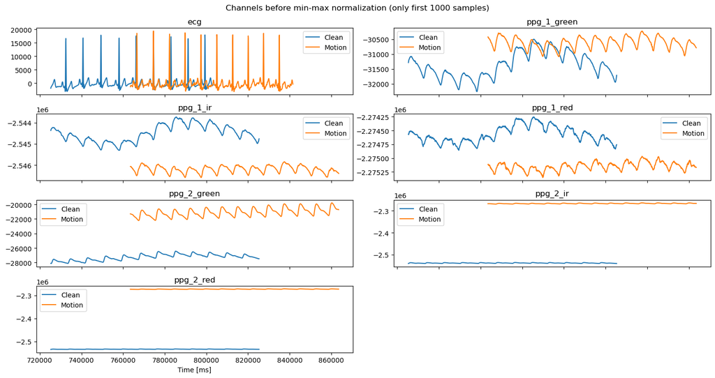

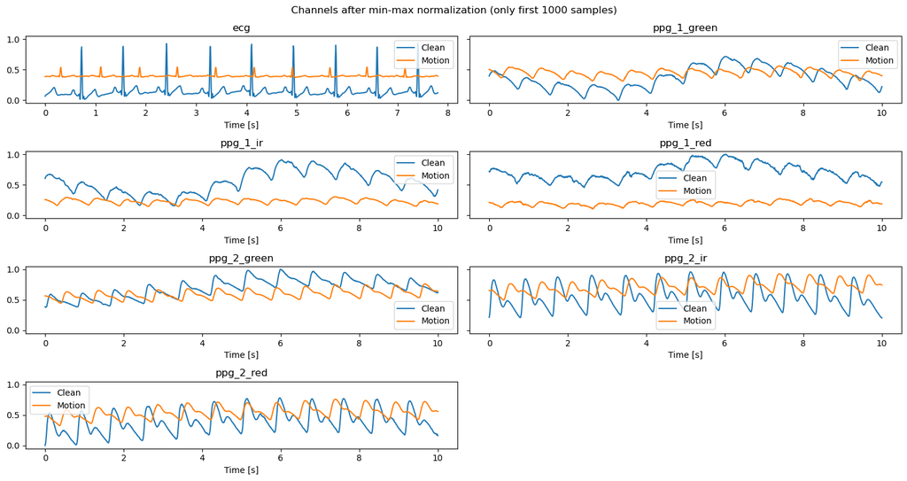

```python
# Get the channel and timestamps columns
sig_cols = sorted([col for col in clean_signals.columns if not 'timestamps' in col])
ts_cols = sorted(list(set(clean_signals.columns) - set(sig_cols)))

# Normalize and turn the timestamps into seconds first
# Let's not overwrite the original dataframes so take copies
normalized_clean = clean_signals.copy()
normalized_motion = motion_signals.copy()

# The columns are the same for both data
for col in clean_signals:

    # Convert timestamps from milliseconds to seconds
    if 'timestamps' in col:
        normalized_clean[col] = (clean_signals[col] - clean_signals[col].values[0]) / 10000
        normalized_motion[col] = (motion_signals[col] - motion_signals[col].values[0]) / 10000
    else:
        # If PPG, flip it
        if 'ppg' in col:
            clean_signals[col] = clean_signals[col] * -1
            motion_signals[col] = motion_signals[col]  * -1

        # Normalize the channels
        normalized_clean[col] = minmax_normalize(clean_signals[col].dropna())
        normalized_motion[col] = minmax_normalize(motion_signals[col].dropna())

# And plot to visualize channels before and after normalization
fig, ax = plt.subplots(4,2, figsize=(15, 8), sharex=True)
fig.suptitle('Channels before min-max normalization (only first 1000 samples)')
for (i, ch), a in zip(enumerate(sig_cols), ax.ravel()):
    sns.lineplot(clean_signals.loc[:1000, :], x = ts_cols[i], y=ch, ax = a, label='Clean').set(title=ch, ylabel='', xlabel='Time [ms]')
    sns.lineplot(motion_signals.loc[:1000, :], x = ts_cols[i], y=ch, ax = a, label='Motion').set(title=ch, ylabel='')

ax.ravel()[-1].axis('off') # remove the last axis as it's empty
fig.tight_layout()
plt.show()

fig, ax = plt.subplots(4,2, figsize=(15, 8), sharey=True)
fig.suptitle('Channels after min-max normalization (only first 1000 samples)')
for (i, ch), a in zip(enumerate(sig_cols), ax.ravel()):
    sns.lineplot(normalized_clean.loc[:1000, :], x = ts_cols[i], y=ch, ax = a, label='Clean').set(title=ch, ylabel='', xlabel='Time [s]')
    sns.lineplot(normalized_motion.loc[:1000, :], x = ts_cols[i], y=ch, ax = a, label='Motion').set(title=ch, ylabel='')

ax.ravel()[-1].axis('off')
fig.tight_layout()
plt.show()
```

##### Calculating average sample frequency for ECG

```python
avg_sample_freq_ecg = 1 / np.mean(np.diff(normalized_clean['timestamps_ecg']))
print('Average sample frequency for ECG:', avg_sample_freq_ecg)
```

```
Average sample frequency for ECG: 128.2051282051282
```

#### 1. Segment the signals into 10 s non overlapping segments. Ideally the code allows for overlapping segmentation.

```python
# calling segment_signal method to segment the signals
segmented_clean = segment_signal(normalized_clean, 'timestamps_ecg', 'ecg', segment_length=10, overlap=0)
segmented_motion = segment_signal(normalized_motion, 'timestamps_ecg', 'ecg', segment_length=10, overlap=0)

print(f"Segments in clean data: {len(segmented_clean)}")
print(f"Segments in motion data: {len(segmented_motion)}")
```

```
Segments in clean data: 12
Segments in motion data: 12
```

The 'overlap' value is set to 0 in this case to ensure that the segments are non-overlapping, meaning each segment is independent and doesn't share data points with the adjacent ones.  
Reference:  
https://stackoverflow.com/questions/60020521/time-series-segmentation-in-python  
https://stackoverflow.com/questions/68974651/time-series-segmentation-using-python

#### 2. Compute ensemble averaged waveform of the heart beats (align found beats from maxima, plot all of them in figure and do samplewise averaged waveform i.e. ensemble averaged).

##### 2.1. For normalised_clean dataset targeting ecg

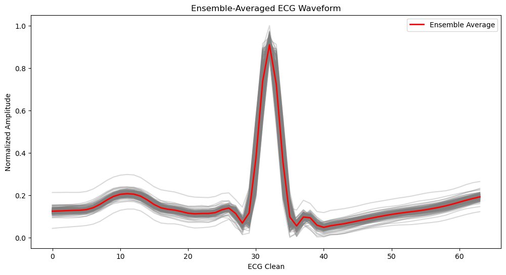

```python
ens_clean, all_beats = calculate_ens(normalized_clean, 'timestamps_ecg', 'ecg')

plt.figure(figsize=(12, 6))
for beat in all_beats:
    plt.plot(beat, alpha=0.3, color='gray')  # Plot individual beats
plt.plot(ens_clean, color='red', linewidth=2, label="Ensemble Average")
plt.title("Ensemble-Averaged ECG Waveform")
plt.xlabel("ECG Clean")
plt.ylabel("Normalized Amplitude")
plt.legend()
plt.show()
```

As per the above figure, gray lines represent individual ECG beats, while the red line represents the ensemble average, which highlights the general shape of the ECG waveform. The clean data represents a well-defined R-peak, followed by other characteristic such as the P-wave, QRS complex, and T-wave. The shaded area around the average line indicates slight variations across different beats, but overall, the waveform remains smooth and consistent. Furthermore, it reflects high signal quality with minimal noise.

##### 2.2. For normalised_motion dataset targeting ecg

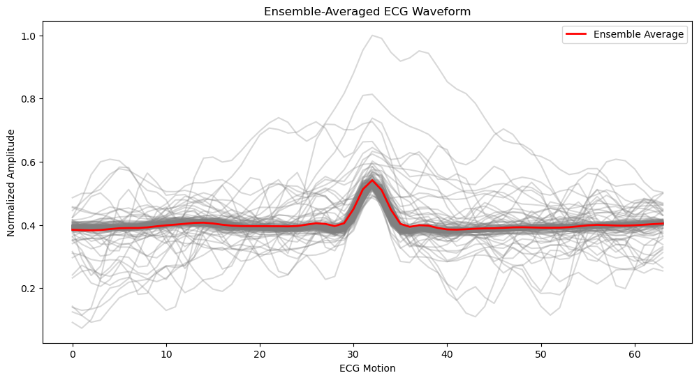

```python
ens_motion, all_beats = calculate_ens(normalized_motion, 'timestamps_ecg', 'ecg')

plt.figure(figsize=(12, 6))
for beat in all_beats:
    plt.plot(beat, alpha=0.3, color='gray')  # Plot individual beats
plt.plot(ens_motion, color='red', linewidth=2, label="Ensemble Average")
plt.title("Ensemble-Averaged ECG Waveform")
plt.xlabel("ECG Motion")
plt.ylabel("Normalized Amplitude")
plt.legend()
plt.show()
```

This figure is about the motion data. In contrast to the clean data, motion artifacts introduce noise, causing greater variability among beats and affecting the waveform. The R-peaks remain identifiable but appear distorted, and other ECG components show more fluctuations. This comparison with clean data helps in understanding how motion artifacts degrade ECG signal quality.

References:  
https://www.researchgate.net/figure/Ensemble-averaging-aligns-multiple-beats-based-on-the-R-wave-peak-location-to-calculate_fig3_325408183  
https://medium.com/towards-data-science/ensemble-averaging-in-medical-signal-processing-17116d0cf0d2

#### 3. Compute time intervals from ensemble averaged waveform. Try to find t-wave from ECG and the diastolic peak from PPG.

##### 3.1. Let's plot the signal first to see the proper peaks in our signal i.e. R interval and T-wave

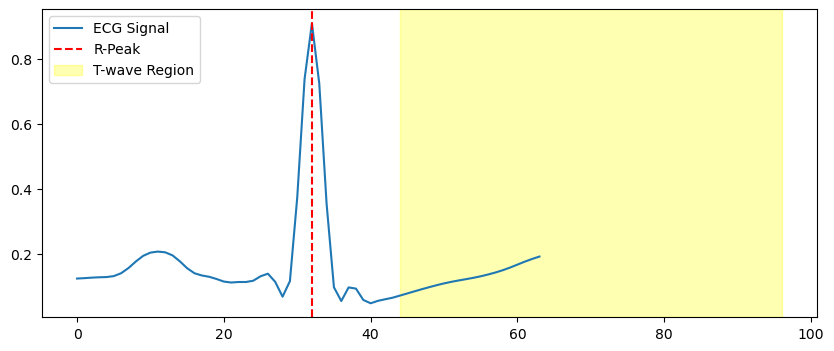

```python
plt.figure(figsize=(10, 4))
plt.plot(ens_clean, label="ECG Signal")
plt.axvline(x=ecg_intervals["R-Peak Index"], color='r', linestyle="--", label="R-Peak")

# highlighting the T-wave region
search_window_start = ecg_intervals["R-Peak Index"] + int(0.10 * avg_sample_freq_ecg)
search_window_end = ecg_intervals["R-Peak Index"] + int(0.50 * avg_sample_freq_ecg)
plt.axvspan(search_window_start, search_window_end, color='yellow', alpha=0.3, label="T-wave Region")

plt.legend()
plt.show()
```

##### 3.2. Computing ECG intervals first for ensemble averaged waveform calculated above for normalised clean

```python
ecg_intervals = compute_time_intervals(ens_clean, avg_sample_freq_ecg)
print("For ECG clean:", ecg_intervals)
```

```
For ECG clean: {'R-Peak Index': 32, 'T-Wave Index': 60, 'QT Interval (s)': 0.2184}
```

##### 3.3. Computing ECG intervals for ensemble averaged waveform calculated above for normalised motion

```python
ecg_intervals = compute_time_intervals(ens_motion, avg_sample_freq_ecg)
print("Computed ECG Time Intervals:", ecg_intervals)
```

```
Computed ECG Time Intervals: {'R-Peak Index': 32, 'T-Wave Index': 54, 'QT Interval (s)': 0.1716}
```

##### 3.4. Computing sample frequency for PPG and finding diastolic peak from PPG for normalised clean

```python
sampling_freq_ppg = 1 / np.mean(np.diff(normalized_clean["timestamps_ppg_1_green"]))  # Use any PPG timestamp column

ppg_results = {}
for signal_col, time_col in zip(
        ['ppg_1_green', 'ppg_1_red', 'ppg_1_ir', 'ppg_2_green', 'ppg_2_red', 'ppg_2_ir'],
        ['timestamps_ppg_1_green', 'timestamps_ppg_1_red', 'timestamps_ppg_1_ir',
         'timestamps_ppg_2_green', 'timestamps_ppg_2_red', 'timestamps_ppg_2_ir']):

    ppg_results[signal_col] = process_ppg_signal(
        normalized_clean[signal_col],
        normalized_clean[time_col],
        sampling_freq_ppg
    )

for key, value in ppg_results.items():
    print(f"{key}: {value}")
```

```
ppg_1_green: {'Systolic Peak Index': 10584, 'Diastolic Peak Index': 10595, 'Time Interval (s)': 0.10999999999999943}
ppg_1_red: {'Systolic Peak Index': 603, 'Diastolic Peak Index': 613, 'Time Interval (s)': 0.09999999999999964}
ppg_1_ir: {'Systolic Peak Index': 10665, 'Diastolic Peak Index': 10669, 'Time Interval (s)': 0.03999999999999204}
ppg_2_green: {'Systolic Peak Index': 599, 'Diastolic Peak Index': 601, 'Time Interval (s)': 0.019999999999999574}
ppg_2_red: {'Systolic Peak Index': 10497, 'Diastolic Peak Index': 10532, 'Time Interval (s)': 0.3499999999999943}
ppg_2_ir: {'Systolic Peak Index': 1908, 'Diastolic Peak Index': 1942, 'Time Interval (s)': 0.3400000000000034}
```

##### 3.4. Computing sample frequency for PPG and finding diastolic peak from PPG for normalised motion

```python
ppg_results = {}
for signal_col, time_col in zip(
        ['ppg_1_green', 'ppg_1_red', 'ppg_1_ir', 'ppg_2_green', 'ppg_2_red', 'ppg_2_ir'],
        ['timestamps_ppg_1_green', 'timestamps_ppg_1_red', 'timestamps_ppg_1_ir',
         'timestamps_ppg_2_green', 'timestamps_ppg_2_red', 'timestamps_ppg_2_ir']):

    ppg_results[signal_col] = process_ppg_signal(
        normalized_motion[signal_col],
        normalized_motion[time_col],
        sampling_freq_ppg
    )

for key, value in ppg_results.items():
    print(f"{key}: {value}")
```

```
ppg_1_green: {'Systolic Peak Index': 6875, 'Diastolic Peak Index': 6889, 'Time Interval (s)': 0.14000000000000057}
ppg_1_red: {'Systolic Peak Index': 9238, 'Diastolic Peak Index': 9283, 'Time Interval (s)': 0.45000000000000284}
ppg_1_ir: {'Systolic Peak Index': 9235, 'Diastolic Peak Index': 9286, 'Time Interval (s)': 0.5100000000000051}
ppg_2_green: {'Systolic Peak Index': 2978, 'Diastolic Peak Index': 3011, 'Time Interval (s)': 0.3299999999999983}
ppg_2_red: {'Systolic Peak Index': 5317, 'Diastolic Peak Index': 5331, 'Time Interval (s)': 0.14000000000000057}
ppg_2_ir: {'Systolic Peak Index': 2979, 'Diastolic Peak Index': 3008, 'Time Interval (s)': 0.28999999999999915}
```

#### 4. Detect/compute a metric/visualize between sinus rhythm and atrial fibrillation signal. Idea is to develop a piece of code that can reveal differences between these signals and be used in atrial fibrillation detection algorithms. Full detection pipeline not needed. The fs in signals is 200.

##### 4.1. Loading the data and ploting the signals in time domain

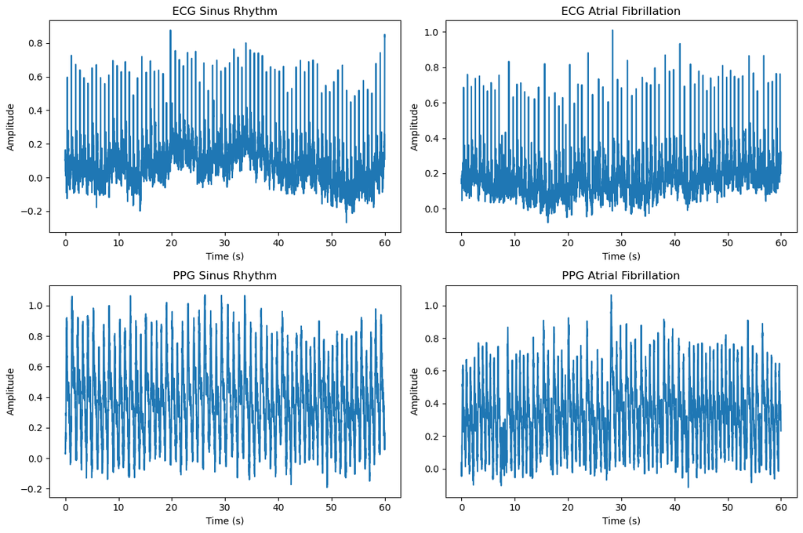

```python
fs = 200

ecg_sinus = np.loadtxt('data/ecg_sinus.csv')
ecg_afib = np.loadtxt('data/ecg_afib.csv')
ppg_sinus = np.loadtxt('data/ppg_sinus.csv')
ppg_afib = np.loadtxt('data/ppg_afib.csv')

plot_signals(ecg_sinus, ecg_afib, ppg_sinus, ppg_afib, fs)
```

The above plots represents time-domain ECG and PPG signals under normal sinus rhythm and atrial fibrillation. The ECG sinus rhythm has a more structured and repeating pattern, indicating a regular heart rhythm. In contrast, the ECG atrial fibrillation appears more chaotic due to irregular electrical activity in the heart. Similarly, the PPG signals reflect variations in blood volume but show less distinct waveform features compared to ECG.

##### 4.2. Implementation of calling Peak Plotting method in which I have call to Peak Detection method

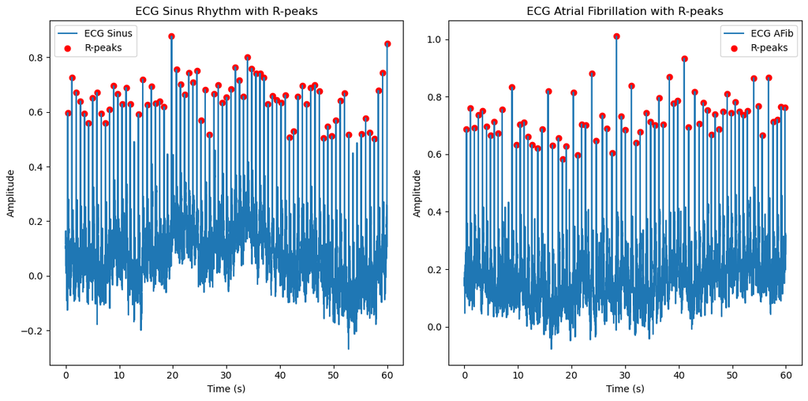

```python
plot_peaks(ecg_sinus, ecg_afib, ecg_sinus_peaks, ecg_afib_peaks, fs)
```

##### 4.3. Call to plot spectral analysis method for ecg_sinus and ecg_afib signals data

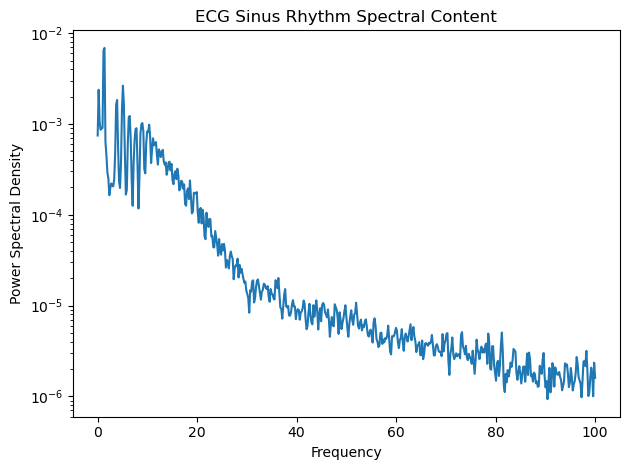

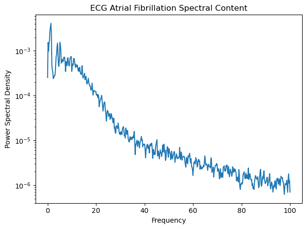

```python
plot_spectral_analysis(ecg_sinus, fs, 'ECG Sinus Rhythm Spectral Content')
plot_spectral_analysis(ecg_afib, fs, 'ECG Atrial Fibrillation Spectral Content')
```

```python
rmssd_sinus, sdnn_sinus = calculate_hrv(ecg_sinus_peaks, fs)
rmssd_afib, sdnn_afib = calculate_hrv(ecg_afib_peaks, fs)

print(f"1. ECG Sinus - RMSSD: {rmssd_sinus:.4f}, SDNN: {sdnn_sinus:.4f}")
print(f"2. ECG AFib - RMSSD: {rmssd_afib:.4f}, SDNN: {sdnn_afib:.4f}")
```

```
1. ECG Sinus - RMSSD: 0.2989, SDNN: 0.2119
2. ECG AFib - RMSSD: 0.3021, SDNN: 0.2025
```

The heart rate measurements show small differences between sinus rhythm and atrial fibrillation. Both rhythms have almost similar RMSSD values, meaning the heart has a similar level of relaxation in both cases. However, the SDNN value is lower in AFib, which indicates less variation in the heart rate and weaker regulation of the heart compared to normal rhythm. This is common in AFib due to the irregular heartbeats.

```python
entropy_sinus = spectral_entropy(ecg_sinus, fs)
entropy_afib = spectral_entropy(ecg_afib, fs)

print(f"Spectral Entropy for Sinus Rhythm: {entropy_sinus:.4f}")
print(f"Spectral Entropy for AFib: {entropy_afib:.4f}")
```

```
Spectral Entropy for Sinus Rhythm: 4.3997
Spectral Entropy for AFib: 4.5460
```

For sinus rhythm, the value suggests a balanced and structured heart rate signal, with a typical level of complexity. This aligns with the rhythmic and predictable nature of a healthy heartbeat. On the other hand, in AFib, the value is high due to the irregular and chaotic heart rate pattern that lies in it.